# Lab 4

Michael Kezner

October 7, 2017

## Question 1

### Part A

**The probability of a team scoring 20 points or fewer:**

```r
pnorm(20, mean = 32, sd = 7)
```

```
[1] 0.04323813
```

The probability of a team scoring 20 points or fewer is **0.04323813**

**Desnity Function:**

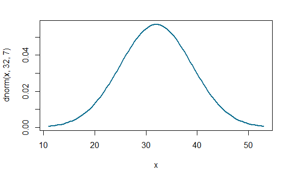

```r
curve(dnorm(x, 32, 7), xlim = c(11, 53), col = "deepskyblue4", lwd = 2)
```

```r
cord.x <- c(11, seq(11, 20, 0.01), 20)
cord.y <- c(0, dnorm(seq(11, 20, 0.01), 32, 7), 0)
curve(dnorm(x, 32, 7), xlim = c(11, 53), col = "deepskyblue4", lwd = 2)
polygon(cord.x, cord.y, col = "deepskyblue1")
```

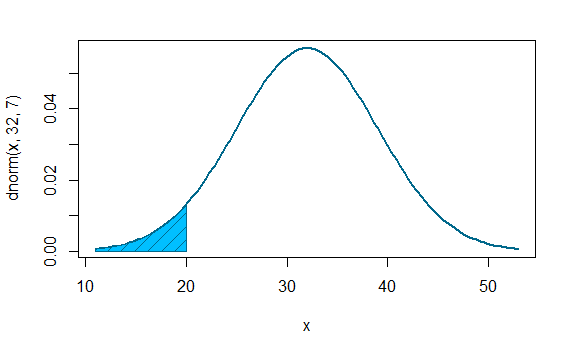

```r
polygon(cord.x, cord.y, col = 'deepskyblue4', density = 10)
```

### Part B

**The probability of a team scoring more than 35 points:**

```r
pnorm(35, 32, 7, lower.tail = FALSE)
```

```
[1] 0.3341176
```

The probability of a team scoring more than 35 points is **0.3341176**

**Density Function:**

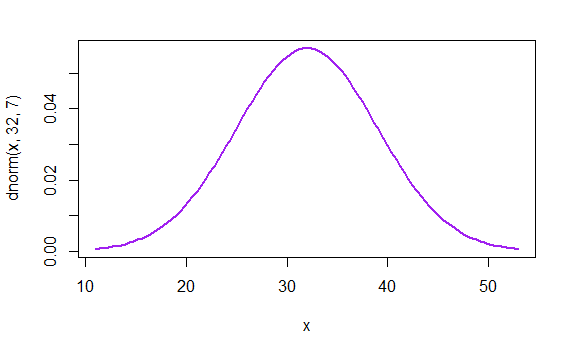

```r
curve(dnorm(x, 32, 7), xlim = c(11, 53), col = 'purple', lwd = 2)
```

```r
cord.x1 <- c(35, seq(35, 53, 0.01), 53)
cord.y1 <- c(0, dnorm(seq(35, 53, 0.01), 32, 7), 0)
curve(dnorm(x, 32, 7), xlim = c(11, 53), col = 'darkorchid4', lwd = 2)
polygon(cord.x1, cord.y1, col = 'orchid1')
```

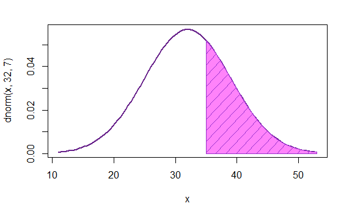

```r
polygon(cord.x1, cord.y1, col = 'darkorchid3', density = 10)
```

### Part C

**The probability of a team scoring between 20 and 40 points**

```r
diff(pnorm(c(20, 40), 32, 7))
```

```
[1] 0.8302129
```

The probability of a team scoring between 20 and 40 points is **0.8302129**

**Density Function:**

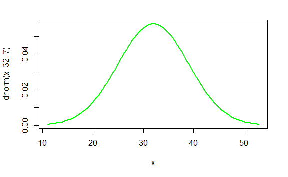

```r
curve(dnorm(x, 32, 7), xlim = c(11, 53), col = 'green', lwd = 2)
```

```r
cord.x2 <- c(20, seq(20, 40, 0.01), 40)
cord.y2 <- c(0, dnorm(seq(20, 40, 0.01), 32, 7), 0)
curve(dnorm(x, 32, 7), xlim = c(11, 53), col = 'mediumseagreen', lwd = 2)
polygon(cord.x2, cord.y2, col = 'mediumspringgreen')
```

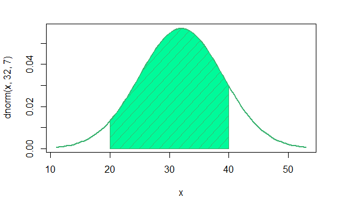

```r
polygon(cord.x2, cord.y2, col = 'mediumseagreen', density = 10)
```

## Question 2

### Part A

**Percent of posts that get less than three comments:**

```r
pexp(3, rate = (1/10))
```

```
[1] 0.2591818
```

The percent of posts that get less than three comments is **25.918%**

**Density Function:**

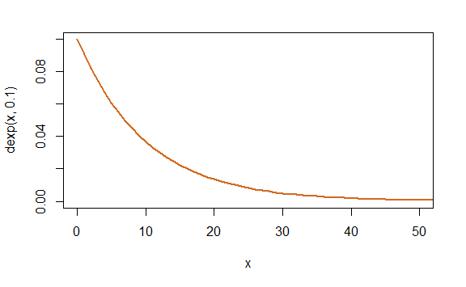

```r
curve(dexp(x, 0.1), to = 100, xlim = c(0, 50), lwd = 2, col = "chocolate")
```

```r
xcord <- c(0, seq(0, 3, 0.01), 3)
ycord <- c(0, dexp(seq(0,3, 0.01), 0.1), 0)
curve(dexp(x, 0.1), to = 100, xlim = c(0, 50), lwd = 2, col = "chocolate4")
polygon(xcord, ycord, col = 'chocolate1')
```

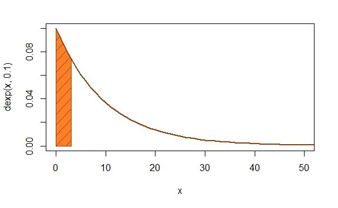

```r
polygon(xcord, ycord, col = 'chocolate4', density = 10)
```

### Part B

**The percent of posts that get more than 20 comments:**

```r
pexp(20, rate = 0.1, lower.tail = FALSE)
```

```
[1] 0.1353353
```

**Density Function:**

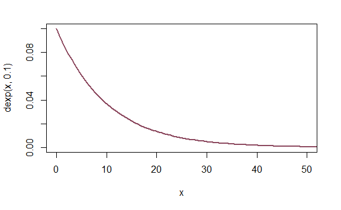

```r
curve(dexp(x, 0.1), to = 60, xlim = c(0, 50), lwd = 2, col = 'palevioletred4')
```

```r
xcord1 <- c(20, seq(20, 60, 0.01), 50)
ycord1 <- c(0, dexp(seq(20, 60, 0.01), 0.1), 0)
curve(dexp(x, 0.1), to = 60, xlim = c(0, 50), lwd = 2, col = 'palevioletred4')
polygon(xcord1, ycord1, col = 'palevioletred1')
```

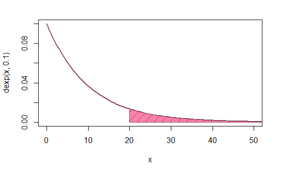

```r
polygon(xcord1, ycord1, col = 'palevioletred4', density = 10)
```

### Part C

**The percent of posts that get between five and ten comments:**

```r
diff(pexp(c(5, 10), 0.1))
```

```
[1] 0.2386512
```

The percent of posts that get between five and ten comments is **23.865%**

**Density Function:**

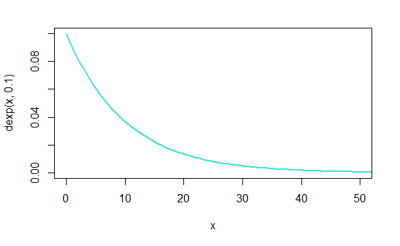

```r
curve(dexp(x, 0.1), to = 60, xlim = c(0, 50), lwd = 2, col = 'turquoise')
```

```r
xcord2 <- c(5, seq(5, 10, 0.01), 10)
ycord2 <- c(0, dexp(seq(5, 10, 0.01), 0.1), 0)
curve(dexp(x, 0.1), to = 60, xlim = c(0, 50), lwd = 2, col = 'turquoise4')
polygon(xcord2, ycord2, col = 'turquoise')
```

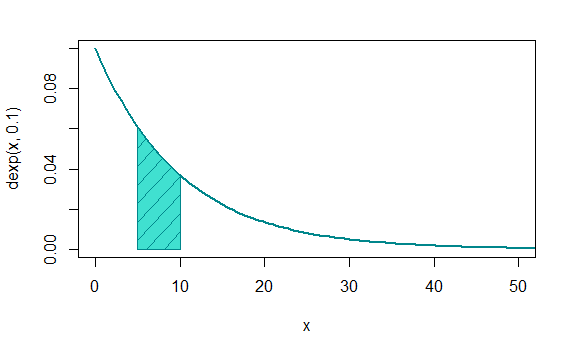

```r
polygon(xcord2, ycord2, col = 'turquoise4', density = 10)
```

## Question 3

### Part A

**First raster with assigned values based on random values from a uniform distribution:**

```r
library(raster)
library(sp)
ras1 <- raster(nrows = 30, ncols = 30, xmn = 0, xmx = 30, ymn = 0, ymx = 30)
ras1
```

```
class       : RasterLayer
dimensions  : 30, 30, 900  (nrow, ncol, ncell)
resolution  : 1, 1  (x, y)
extent      : 0, 30, 0, 30  (xmin, xmax, ymin, ymax)
coord. ref. : +proj=longlat +datum=WGS84
```

**First Raster Plot:**

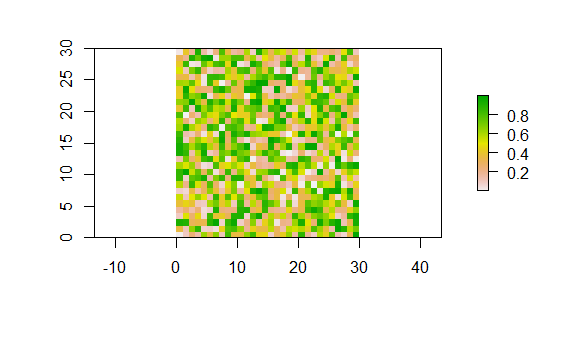

```r
ras1[] <- runif(ncell(ras1))
plot(ras1)
```

**First Raster Histogram:**

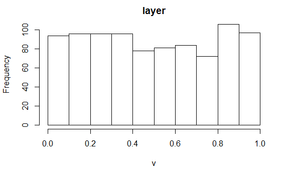

```r
hist(ras1)
```

### Part B

**Second raster with assigned values based on random values from a normal distribution:**

```r
ras2 <- raster(nrows = 30, ncols = 30, xmn = 0, xmx = 30, ymn = 0, ymx = 30)
ras2
```

```
class       : RasterLayer
dimensions  : 30, 30, 900  (nrow, ncol, ncell)
resolution  : 1, 1  (x, y)
extent      : 0, 30, 0, 30  (xmin, xmax, ymin, ymax)
coord. ref. : +proj=longlat +datum=WGS84
```

**Second Raster Plot:**

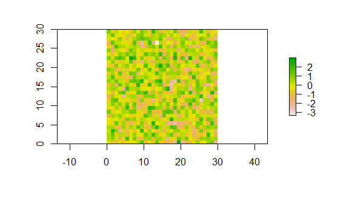

```r
ras2[] <- rnorm(ncell(ras2))
plot(ras2)
```

**Second Raster Histogram:**

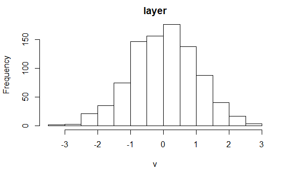

```r
hist(ras2)
```

### Part C

**Third raster with assigned values based on cell-by-cell addition of the first and second raster:**

```r
ras3 <- ras1 + ras2
ras3
```

```
class       : RasterLayer
dimensions  : 30, 30, 900  (nrow, ncol, ncell)
resolution  : 1, 1  (x, y)
extent      : 0, 30, 0, 30  (xmin, xmax, ymin, ymax)
coord. ref. : +proj=longlat +datum=WGS84
data source : in memory
names       : layer
values      : -2.639165, 3.287515  (min, max)
```

**Third Raster Plot:**

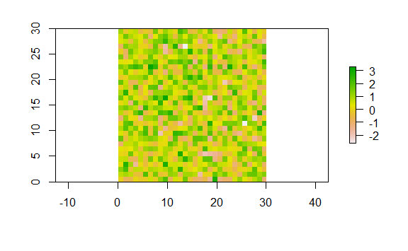

```r
plot(ras3)
```

**Third Raster Histogram:**

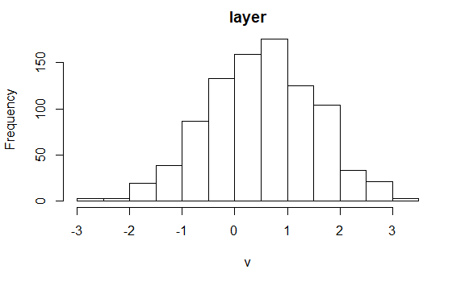

```r
hist(ras3)
```

### Part D

**Mean value of the third raster:**

```r
cellStats(ras3, "mean")
```

```
[1] 0.5121868
```

The mean value of the third raster is **0.5121868**

**Reclassifying the third raster as a binary image:**

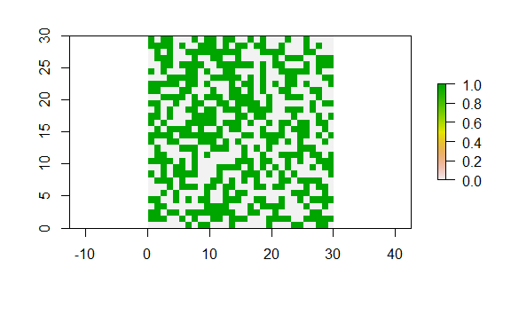

```r
ras4 <- ras3
ras4[ras3 > 0.5121868] <- 1
ras4[ras3 <= 0.5121868] <- 0
plot(ras4)
```

**Saving the reclassifyed image to my working directory as a TIFF image:**

```r
library(rgdal)
writeRaster(ras4, filename = "lab4ras4.tif", overwrite = TRUE)
```